# Metropolis-coupled Markov Chain Monte Carlo (MC3)

Sentient Potato

March 26, 2022

# What is MC3? What is it used for?

Markov chain Monte Carlo (MCMC) is an algorithm to sample from a probability distribution. However, MCMC samplers can sometimes get “stuck” in local optima of multi-modal distributions. Metropolis-coupled MCMC (MC3) extends the MCMC algorithm in a way that helps sample from difficult target distributions.

# Metropolis-Hastings Algorithm for MCMC Sampling

To explain the MC3 algorithm, it will first be useful to briefly review the MCMC algorithm, where updates are made using Metropolis-Hastings steps. A parameter $\theta$ is distributed according to a probability distribution $F$ with probability density function $f$. We want to sample from the distribution of $\theta$. We can generate $S$ samples from the distribution with the following algorithm:

0. Begin with a starting value of $\theta$, $\theta^0$
1. For $s$ in 1, …, $S$
   1. Propose a new value $\theta^\ast$ from a *proposal density* $q$ that is typically a function of $\theta^{s-1}$
   2. Calculate the following ratio $r$:
      $$r = \dfrac{f\left(\theta^\ast\right)q\left(\theta^{s-1}\mid\theta^\ast\right)}{f\left(\theta_{s-1}\right)q\left(\theta^\ast\mid\theta^{s-1}\right)}.$$
      Often we do this on the log scale for numerical stability:
      $$\log\left(r\right) = \log\left[f\left(\theta^\ast\right)\right] + \log\left[q\left(\theta^{s-1}\mid\theta^\ast\right)\right] - \log\left[f\left(\theta^{s-1}\right)\right] - \log\left[q\left(\theta^\ast\mid\theta^{s-1}\right)\right].$$
   3. “Accept the proposal”, i.e. set $\theta^s = \theta^\ast$ with probability
      $$\pi = \min\left\{1, r\right\};$$
      we set $\theta^s = \theta^{s-1}$ otherwise. We typically do this by drawing a single standard uniform deviate $u$ and accept the proposal if
      $$\log\left(u\right) < \log\left(r\right).$$
      This manner of updating is called a Metropolis-Hastings, or MH, step.

Note that if $q$ is a symmetric distribution, then $q\left(\theta_{s-1}\mid\theta^\ast\right) = q\left(\theta^\ast\mid\theta^{s-1}\right)$ and we can simplify $r$ to

$$\begin{align}
r & = \dfrac{f\left(\theta^\ast\right)}{f\left(\theta^{s-1}\right)}, \\
\log\left(r\right) & = \log\left[f\left(\theta^\ast\right)\right] - \log\left[f\left(\theta^{s-1}\right)\right];
\end{align}$$

then, strictly speaking this is only a Metropolis step, though in practice people often still call it an MH step.

# The MC3 Algorithm

In Metropolis-coupled MCMC, we construct $N$ parallel chains at inverse “temperatures” $\beta_1 = 1 > \beta_2 > \dots > \beta_N > 0$. Parameter updates for each chain are done via MH steps, but the acceptance probability for each chain $i$ is raised to the power of $\beta_i$, so that “hotter” chains have a “melted” target distribution surface that allows proposals to be more readily accepted. (Note that chains are indexed via subscript and iterations are indexed via superscript). Periodically, we attempt to swap states between chains via a Metropolis update; the probability of accepting a swap between chains $i$ and $j$ at iteration $s$ is

$$\begin{equation}
p\left(\text{swap }i\text{ with }j\right) \triangleq \psi_{i,j}^s = \min\left\{1, \dfrac{f\left(\theta_i^s\right)^{\beta_j}f\left(\theta_j^s\right)^{\beta_i}}{f\left(\theta_i^s\right)^{\beta_i}f\left(\theta_j^s\right)^{\beta_j}}\right\}.
\end{equation}$$

Commonly, the period between swaps is simply to attempt a swap every iteration, though that need not be the case. Let $t$ be the interval between state swaps. So, the full MC3 algorithm is

0. For each chain $i$ in 1, …, $N$, set a starting value of $\theta_i$, $\theta_i^0$
1. For $s$ in 1, …, $S$
   1. For $i$ in 1, …, $N$
      1. Propose a new value $\theta_i^\ast$ from proposal density $q$
      2. Calculate $r$ as in step 1a of the Metropolis-Hastings MCMC algorithm given $\theta_i^\ast$ and $\theta_i^{s-1}$
      3. Set $\theta_i^s = \theta_i^\ast$ with probability $\min\{1, r\}$; set $\theta_i^s = \theta_i^{s-1}$ otherwise.
   2. If $s % t = 0$, then for $i$ in 1, …, $N-1$, swap states between $i$ and $i+1$ (i.e., set $\theta_i^s = \theta_{i+1}^s$ and $\theta_{i+1}^s = \theta_i^s$) with probability $\psi_{i,i+1}^s$.

Note that only the “cold” chain (with $\beta = 1$) is a proper Markov chain that may be retained for inference. However, the “hot” chains can more freely explore the surface of the target distribution, in essence formulating an elaborate proposal density for new values for the cold chain.

# An Example

Suppose our target distribution is a normal mixture with pdf

$$f(\theta) = 0.5 \mathcal{N}\left(\theta; -5, 1\right) + 0.5 \mathcal{N}\left(\theta; 5, 1\right):$$

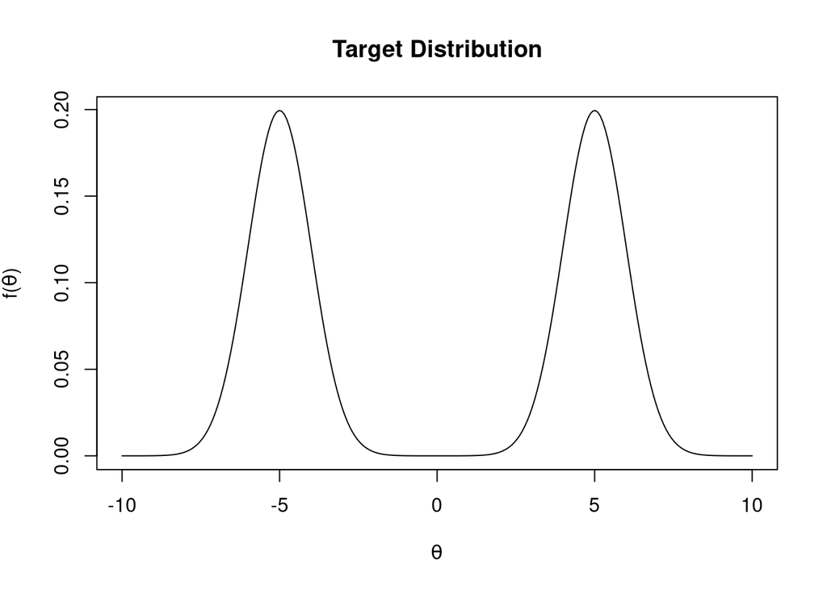

```r
target = function(theta) 0.5 * (dnorm(theta, mean = -5) + dnorm(theta, mean = 5))
example_range = seq(from = -10, to = 10, length.out = 250)
plot(
    x = example_range, y = target(example_range), type = "l",
    xlab = bquote(theta), ylab = bquote("f("*theta*")"),
    main = "Target Distribution"
)
```

MCMC sampling may struggle to characterize this target distribution:

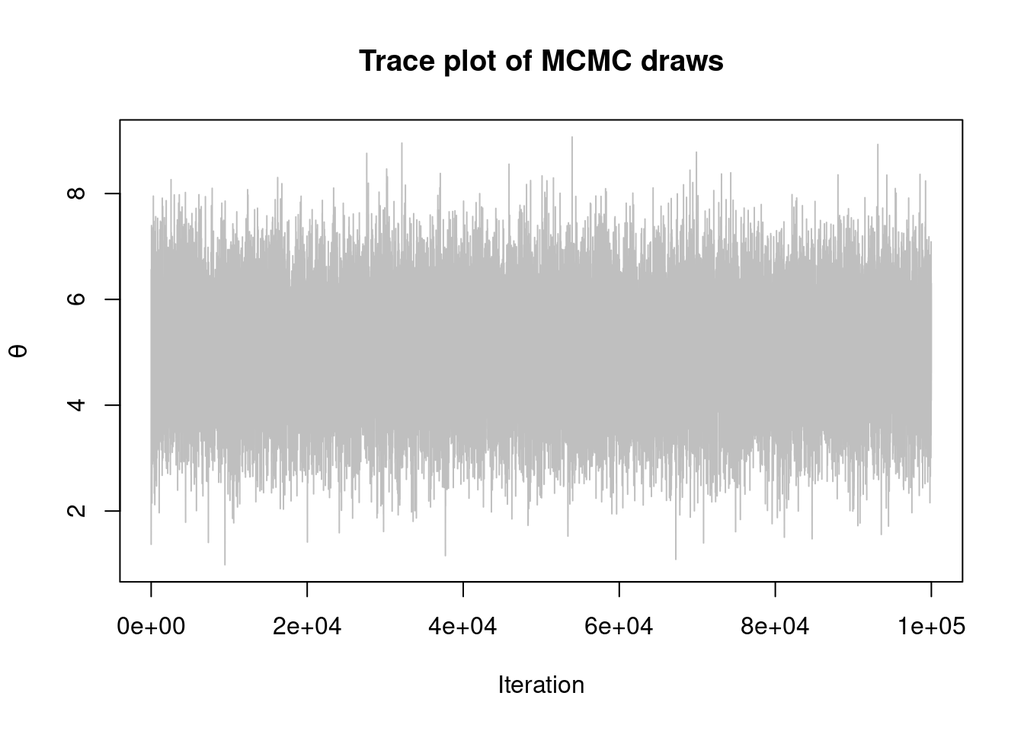

```r
logtarget = function(theta) log(target(theta))
propose = function(theta, sd = 1) rnorm(n = 1, mean = theta, sd = sd)
accept = function(proposal, theta, logtarget) {
    u = runif(n = 1, min = 0, max = 1)
    logratio = logtarget(proposal) - logtarget(theta)
    return(isTRUE(log(u) < logratio))
}
S = 1e5
theta = 0
draws = numeric(S)
set.seed(42)
for ( s in 1:S ) {
    proposal = propose(theta)
    if ( accept(proposal, theta, logtarget) ) {
        theta = proposal
    }
    draws[s] = theta
}
plot(
    x = seq_along(draws), y = draws, type = "l", col = "#80808080",
    xlab = "Iteration", ylab = bquote(theta), main = "Trace plot of MCMC draws"
)
```

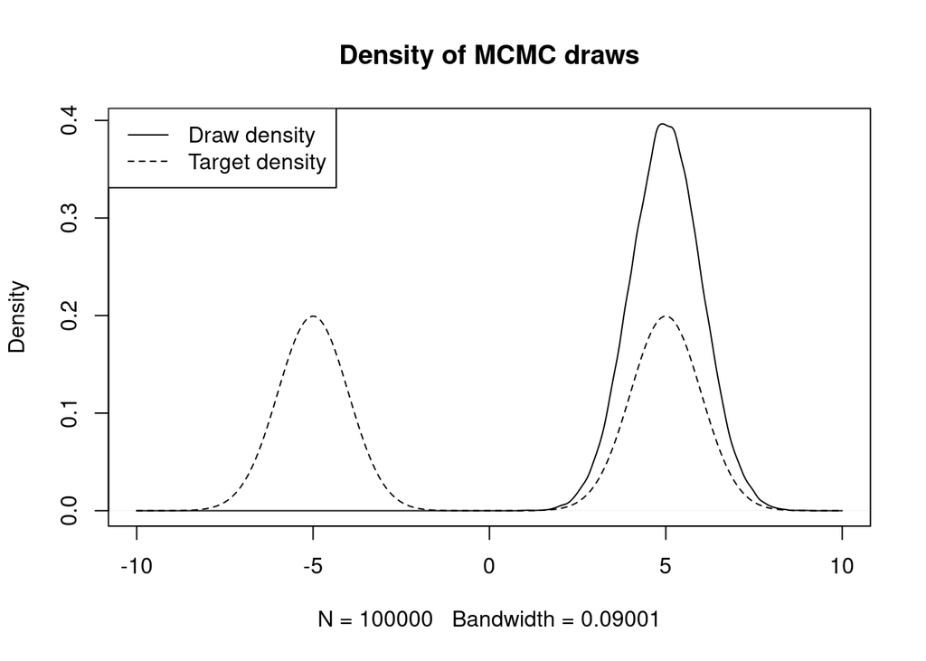

```r
plot(density(draws, from = -10, to = 10), main = "Density of MCMC draws")
lines(x = example_range, y = target(example_range), lty = 2)
legend("topleft", lty = c(1, 2), legend = c("Draw density", "Target density"))
```

However, MC3 sampling can easily characterize the target distribution:

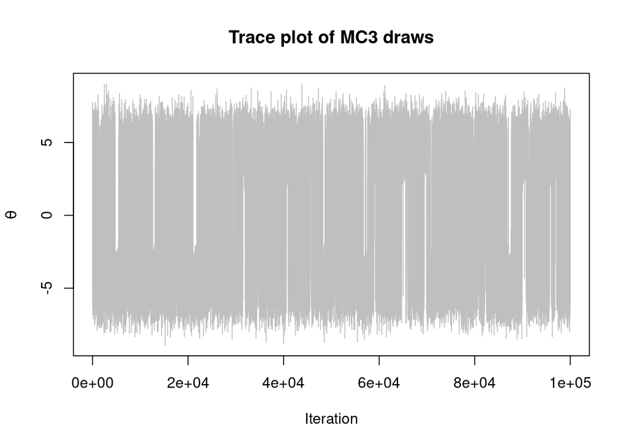

```r
beta = 1 / c(1, 2, 4, 8) ## arbitrarily chose this temperature schedule
accept = function(proposal, theta, logtarget, beta = 1) {
    u = runif(n = 1, min = 0, max = 1)
    logratio = logtarget(proposal) - logtarget(theta)
    return(isTRUE(log(u) < (beta * logratio)))
}
S = 1e5
N = length(beta)
theta = rep(0, N)
draws = numeric(S)
set.seed(42)
for ( s in 1:S ) {
    for ( i in 1:N ) {
        proposal = propose(theta[i])
        if ( accept(proposal, theta[i], logtarget, beta[i]) ) {
            theta[i] = proposal
        }
    }
    for ( i in 1:(N-1) ) {
        log_p_i = logtarget(theta[i])
        log_p_j = logtarget(theta[i+1])
        logpsi = beta[i] * (log_p_j - log_p_i) + beta[i+1] * (log_p_i - log_p_j)
        u = runif(n = 1, min = 0, max = 1)
        if ( isTRUE(log(u) < logpsi) ) {
            tmp = theta[i]
            theta[i] = theta[i+1]
            theta[i+1] = tmp
        }
    }
    draws[s] = theta[1]
}
plot(
    x = seq_along(draws), y = draws, type = "l", col = "#80808080",
    xlab = "Iteration", ylab = bquote(theta), main = "Trace plot of MC3 draws"
)
```

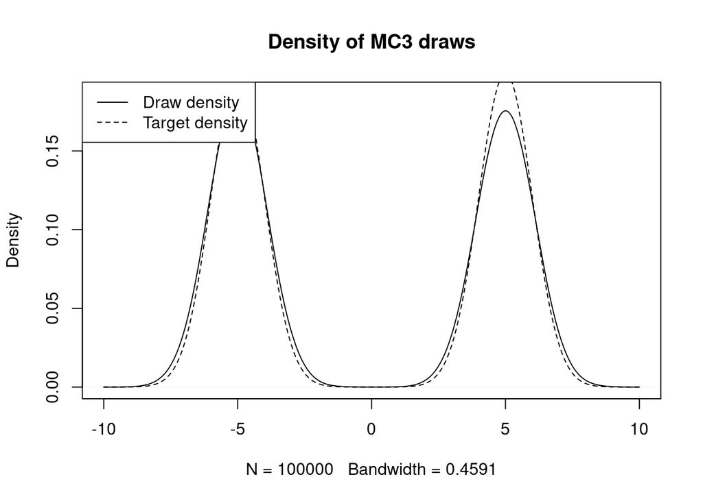

```r
plot(density(draws, from = -10, to = 10), main = "Density of MC3 draws")
lines(x = example_range, y = target(example_range), lty = 2)
legend("topleft", lty = c(1, 2), legend = c("Draw density", "Target density"))
```